# Meta-Analysis Examples

# Simple Data Structures

Here, we’ll use an example dataset taken from the [`metafor`](http://www.metafor-project.org/doku.php/analyses:normand1999) website, which also comes preloaded with the `metafor` package.<sup>1</sup>

```r
library(metafor)
```

```r
library(concurve)
library(ggplot2)
dat.hine1989
```

```
#>   study         source n1i n2i ai ci
#> 1     1  Chopra et al.  39  43  2  1
#> 2     2       Mogensen  44  44  4  4
#> 3     3    Pitt et al. 107 110  6  4
#> 4     4   Darby et al. 103 100  7  5
#> 5     5 Bennett et al. 110 106  7  3
#> 6     6 O'Brien et al. 154 146 11  4
```

I will quote Wolfgang here, since he explains it best,

> "As described under help(dat.hine1989), variables **n1i** and **n2i** are the number of patients in the lidocaine and control group, respectively, and **ai** and **ci** are the corresponding number of deaths in the two groups. Since these are 2×2 table data, a variety of different outcome measures could be used for the meta-analysis, including the risk difference, the risk ratio (relative risk), and the odds ratio (see Table III). Normand (1999) uses risk differences for the meta-analysis, so we will proceed accordingly. We can calculate the risk differences and corresponding sampling variances with:

```r
dat <- escalc(measure = "RD", n1i = n1i, n2i = n2i, ai = ai, ci = ci, data = dat.hine1989)
dat
```

```
#>   study         source n1i n2i ai ci     yi     vi
#> 1     1  Chopra et al.  39  43  2  1 0.0280 0.0018
#> 2     2       Mogensen  44  44  4  4 0.0000 0.0038
#> 3     3    Pitt et al. 107 110  6  4 0.0197 0.0008
#> 4     4   Darby et al. 103 100  7  5 0.0180 0.0011
#> 5     5 Bennett et al. 110 106  7  3 0.0353 0.0008
#> 6     6 O'Brien et al. 154 146 11  4 0.0440 0.0006
```

> "Note that the **yi** values are the risk differences in terms of proportions. Since Normand (1999) provides the results in terms of percentages, we can make the results directly comparable by multiplying the risk differences by 100 (and the sampling variances by $100^{2}$):

```r
dat$yi <- dat$yi * 100
dat$vi <- dat$vi * 100^2
```

We can fit a fixed-effects model with the following

```r
fe <- rma(yi, vi, data = dat, method = "FE")
```

Now that we have our metafor object, we can compute the consonance function using the `curve_meta()` function.

```r
fecurve <- curve_meta(fe)
```

Now we can graph our function.

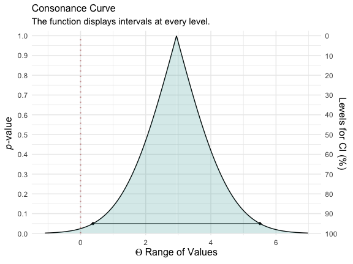

```r
ggcurve(fecurve[[1]], nullvalue = TRUE)
```

We used a fixed-effects model here, but if we wanted to use a random-effects model, we could do so with the following, which will use a restricted maximum likelihood estimator for the random-effects model

```r
re <- rma(yi, vi, data = dat, method = "REML")
```

And then we could use `curve_meta()` to get the relevant list

```r
recurve <- curve_meta(re)
```

Now we can plot our object.

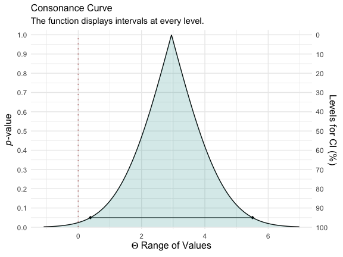

```r
ggcurve(recurve[[1]], nullvalue = TRUE)
```

We could also compare our two models to see how much consonance/overlap there is

```
#> [1] "AUC = Area Under the Curve"
#> [[1]]
#>
#>
#>  AUC 1   AUC 2   Shared AUC   AUC Overlap (%)   Overlap:Non-Overlap AUC Ratio
#> ------  ------  -----------  ----------------  ------------------------------
#>  2.084   2.084        2.084               100                             Inf
#>
#> [[2]]
```

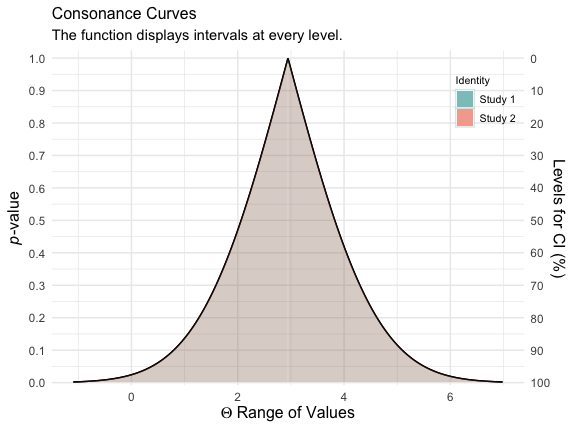

```r
curve_compare(fecurve[[1]], recurve[[1]], plot = TRUE)
```

The results are practically the same and we cannot actually see any difference, and the AUC % overlap also indicates this.

# Complex Data Structures

`concurve` can also handle complex data structures from `metafor` that are clustered.

```r
### copy data from Berkey et al. (1998) into 'dat'
dat <- dat.berkey1998

### construct list of the variance-covariance matrices of the observed outcomes for the studies
V <- lapply(split(dat[, c("v1i", "v2i")], dat$trial), as.matrix)

### construct block diagonal matrix
V <- bldiag(V)

### fit multivariate model
res <- rma.mv(yi, V, mods = ~ outcome - 1, random = ~ outcome | trial, struct = "UN", data = dat)

### results based on sandwich method
(a <- robust(res, cluster = dat$trial))
```

```
#>
#> Number of outcomes:   10
#> Number of clusters:   5
#> Outcomes per cluster: 2
#>
#> Test of Moderators (coefficients 1:2):
#> F(df1 = 2, df2 = 3) = 41.6138, p-val = 0.0065
#>
#> Model Results:
#>
#>            estimate      se     tval    pval    ci.lb    ci.ub
#> outcomeAL   -0.3392  0.1010  -3.3597  0.0437  -0.6605  -0.0179  *
#> outcomePD    0.3534  0.0675   5.2338  0.0136   0.1385   0.5683  *
#>
#> ---
#> Signif. codes:  0 '***' 0.001 '**' 0.01 '*' 0.05 '.' 0.1 ' ' 1
```

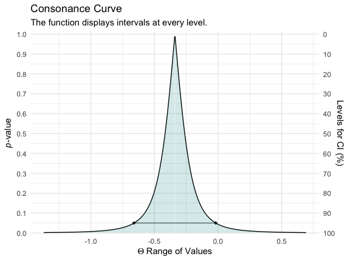

```r
l <- concurve::curve_meta(res, method = "uni", robust = TRUE, cluster = dat$trial, adjust = TRUE, steps = 1000)

ggcurve(data = l[[1]], type = "c") +
  theme_minimal()
```

# References

1. Viechtbauer W. *Conducting Meta-Analyses in R with the Metafor Package*.; 2010. https://www.jstatsoft.org/v36/i03/.